# Tarea 2 Semestre Otoño 2021

Felipe Jorquera Díaz, Constanza Peña Soto, Matías Salinas Muñoz

2 de junio de 2021

**Universidad de Chile**

**Ingeniería Industrial**

**IN5602**: Marketing II

**Prof**: Marcel Goic

**Auxs**: R. Cerda, JP. Coddou, G.Mora, F. Moraga, A .Muñoz

## Enunciado: OtakuFest

Un canal televisivo ha observado desde las sombras cómo el Animé ha aumentado su popularidad de manera exponencial durante el último tiempo, por lo que se dispone a realizar su próxima apuesta por la animación japonesa y busca elegir qué serie comenzar a emitir. Para ello esta auspiciando el famoso festival “OtakuFest” lugar al que asisten tanto fans de la cultura japonesa, como los denominados *Expertos*, personas capaces de pasar más de 24 horas seguidas frente a una pantalla a disfrutar de una serie acompañados de su infaltable dosis de maruchan. Los Expertos han estado observando 4 tipos distintos de anime durante el último tiempo: 1.Hunter x Hunter, 2.Dragon Ball, 3.Naruto y 4.My Hero Academia. En el final del evento, los expertos votaron para escoger al animé de su preferencia dentro de las elecciones para decidir el ganador , el cual será finalmente transmitido en el canal televisivo.

Los resultados de la votación están incluidos en la base de datos “Anime.csv”, la cual posee una estructura de panel, en la cual cada fila representa un capítulo de la serie correspondiente, con sus respectivas características. La variable “Elección” toma el valor 1 si es que el Experto votó por dicho capítulo y 0 si no. El experto debe realizar su votación comparando el n-ésimo capítulo de cada serie y elegir de entre los cuatro cuál es el que más le gustó. Por ejemplo, luego de ver el primer capítulo de cada uno de los 4 anime, el experto elige un sólo ganador de los 4. Para no sobre-cargar cognitivamente a los Expertos, la evaluación selimitó a la evaluación de los primeros 12 capitulos de cada serie.

El equipo de programación piensa que esta información puede ser muy relevante para guiar las decisiones de programación. En estas decisión es importante considerar no solo cuál es la serie que tiene mayor rating sino que también el público al que les resulta más atractivo y si hubieran dinámicas en la evaluación en el tiempo. Quizás hay algunas series que, aunque en el global pueden ser bien evaluadas, podrían una partida lenta con baja preferencia en los primeros capítulos. Aunque hay un amplio historial de series existosas que han partido con bajo rating, es útil indentificar estas dinámicas para que, en caso de emitirse, el lanzamiento sea apoyado con estrategias promocionales que consoliden la propuesta de valor.

#### **Preguntas**

1. (0 puntos) Explore los datos para poder entender qué variables podrían ser más influyentes en el hecho de que un experto elija un anime.
2. (2,0 puntos) Defina un modelo Logit y Mixed Logit multinomiales para estudiar las razones que llevan a un experto a elegir animes. Interprete los coeficientes y calcule la probabilidad de que una mujer de 25 años elija el anime *naruto* para el modelo logit multinomial.
3. (1,0 puntos) Construya un modelo Probit que capture los elementos de elección principales y comente sobre cómo se interpretan sus coeficientes.
4. (2,0 puntos) Utilizando lo aprendido de los modelos anteriores, construya dos modelos de *machine and learning* diferentes y compárelos con los modelos logits y probits estimados anteriormente, para ello calcule la matriz de confusión de cada modelo respecto a su predicción y utilice métricas derivadas a partir de esta para la comparación de los modelos.
5. (1,0 puntos) Resuma sus aprendizajes principales en un máximo de 4 tablas o figuras. Redacte de manera concisa sus resultados tal como los reportaría al departamento comercial interesado en informarse de la preferencia de los expertos. Agregue cualquier conclusión o idea que le parezca relevante de comunicar para que los representantes del canal de televisión tomen la mejor estrategia de programación televisiva.

#### **Reglas del juego**

- Las tareas buscan replicar parcialmente las labores a las que se enfrentarían en el análisis de datos en una organización para el apoyo en la toma de decisiones. Por esto, se han propuesto preguntas relativamente abiertas que requieren que ustedes discutan y decidan cual es el mejor enfoque de solución. Les pedimos que se involucren tempranamente en el desarrollo de la tarea para tener una discusión enriquecedora.
- Todas las dudas, comentarios y errores publicarlos exclusivamente en el foro de u-cursos. De esta forma todos se benefician de las respuestas ofrecidas.
- Consideramos que es muy importante que logren escribir un informe conciso con una redacción acorde de un informe técnico profesional, los análisis y las conclusiones que obtengan de cada pregunta es en específico lo que debe declararse. La presentación y comunicación de resultados es parte integral de la tarea y por tanto será evaluada cuidadosamente.
- La tarea se desarrolla en grupos de máximo 3 integrantes. No hay excepciones. El entregable principal es un único markdown separado en tres tabs (a través de la opción .tabset). En el primer tab incluya todo el desarrollo de la tarea adecuadamente comentado. El segundo tab incluya el resumen de sus resultado de acuerdo a lo pedido en la pregunta 6. Este segundo tab es el que usarán en caso de que les corresponda presentar sus resultados. Considere el tercer tab como de anexos y puede incluir aquí cualquier resultado complementario. Para entregar sus resultados suba vía u-cursos un único archivo comprimido llamado t2-A1-A2-A3.zip, donde A1, A2 y A3 es el primer apellido de los integrantes del grupo. Incluya tanto el archivo .html de salida del markdown como los códigos fuentes que permitan reproducir sus resultados.
- Para la pregunta 6 consideramos que 4 figuras son suficientes para resumir los aprendizajes más relevantes, pero si están convencidos de que agregar una figura adicional es absolutamente necesaria, ¡adelante!
- La fecha de entrega de la tarea es el día miércoles 23 de Junio a las 09:00 hrs, sin excepciones y no habrá plazo extra para la entrega. Si por algún motivo de fuerza mayor se ve imposibilitado de entregar la tarea en el plazo estipulado, deberá escribir directamente al profesor explicando su situación. El profesor decidirá el curso de acción de acuerdo a los méritos del caso.
- Recuerde que tenemos contempladas dos sesiones de presentaciones de las tareas. La primera sesión, a realizarse el día jueves 17 de Junio, está destinada a que compartan sus avances y podamos identificar de manera conjunta cuáles podrían ser dificultades técnicas que requieran orientación adicional. La segunda sesión, a realizarse el día jueves 6 de Mayo, está destinada para que expongan los resultados más relevantes de su trabajo y resuman sus principales aprendizajes, para que tanto los compañeros como el equipo docente puedan proveer retroalimentación. Todos los grupos deben estar disponibles para presentar en ambas ocasiones, pero si hay grupos voluntarios se les dará preferencia. Las presentaciones tendrán una duración máxima de 10 minutos y no es necesario que preparen material adicional. Esperamos que la salida del markdown sea lo suficientemente explicativa para comunicar sus resultados.
- El equipo docente considera que la copia de tareas atenta en contra de tu aprendizaje y por tanto aplicará todas las medidas que estén a su disposición para desincentivar esta mala práctica.

## Preliminares

Escribe acá todos los comandos que necesitas ejecutar antes de abordar las preguntas de la tarea (carga de librerías, lectura de datos, limpieza de la data, transformación de variables y todo lo que necesites)

#### Preparación Tarea

Subimos el dataset

## Desarrollo

Documenta acá el desarrollo de tu tarea por pregunta.

#### Pregunta 1

(0 puntos) Explore los datos para poder entender qué variables podrían ser más influyentes en el hecho de que un experto elija un anime.

Primero analizaremos las correlaciones de las variables numéricas:

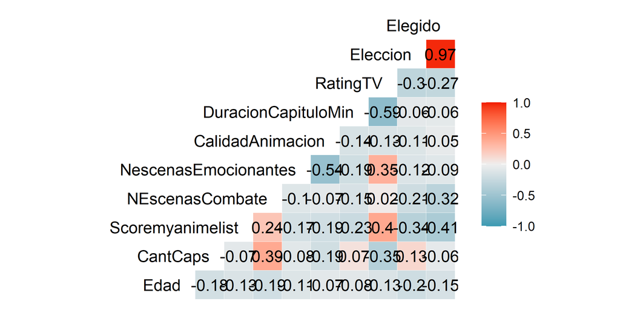

Algunas correlaciones importantes son las siguientes: * Los animes con mayor cantidad de capitulos tienen una mayor número de escenas de combate, pero también tiene un menor rating. * El *score* de anime list aumenta con la cantidad de escenas de combate, además, tiene un mayor rating de televisión.

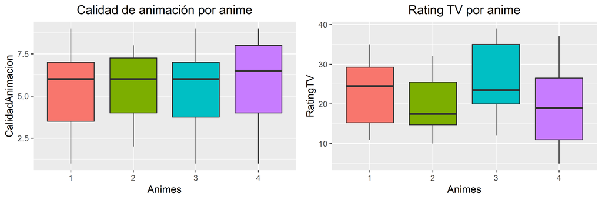

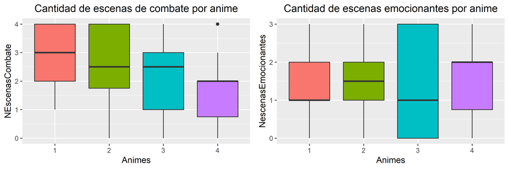

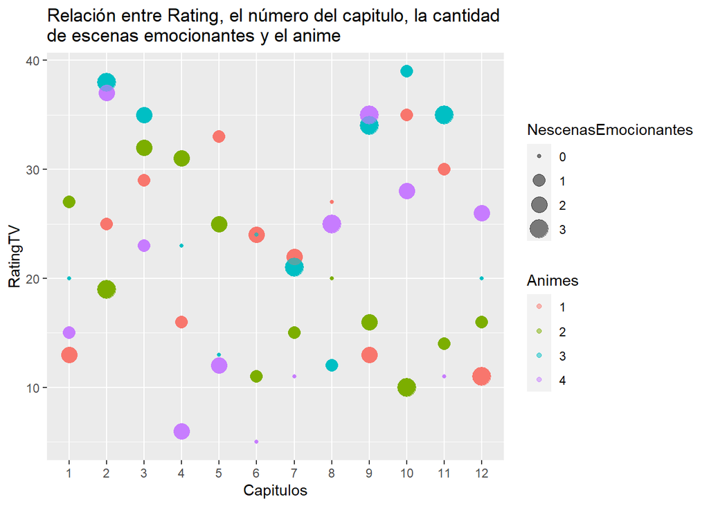

```r
ggplot(anime, aes(x=Capitulos, y=RatingTV, size=NescenasEmocionantes, color=Animes))+
  geom_point(alpha = 0.5)+
  labs(title = "Relación entre Rating, el número del capitulo, la cantidad\nde escenas emocionantes y el anime")+
  scale_size(range = c(1, 6))
```

[figure not shown]

```r
ggplot(anime, aes(x=Capitulos, y=RatingTV, size=DuracionCapituloMin, color=Animes))+
  geom_point(alpha = 0.5)+
  labs(title = "Relación entre Rating, el número del capitulo, la cantidad\nde escenas de combate y el anime")
```

Luego, podemos filtrar el dataset, obteniendo solamente un dataset con las elecciones que hizo el participante para determinado capítulo, esto nos entrega un dataset donde 1000 participantes entregan sus preferencias para cada capítulo (en total 12).

```r
anime1 <- anime[anime$Eleccion == 1, ]
anime1 <- subset(anime1, select=-c(Animes))
```

[figure not shown]

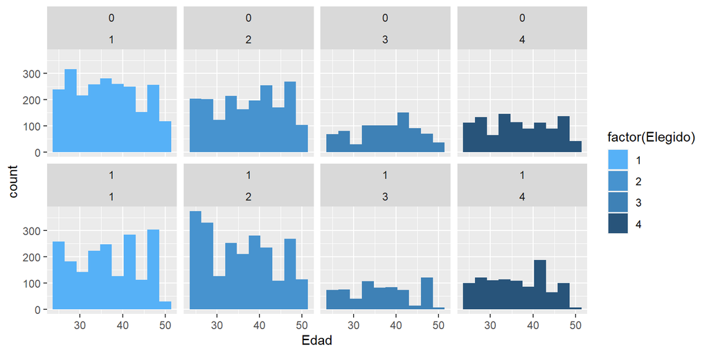

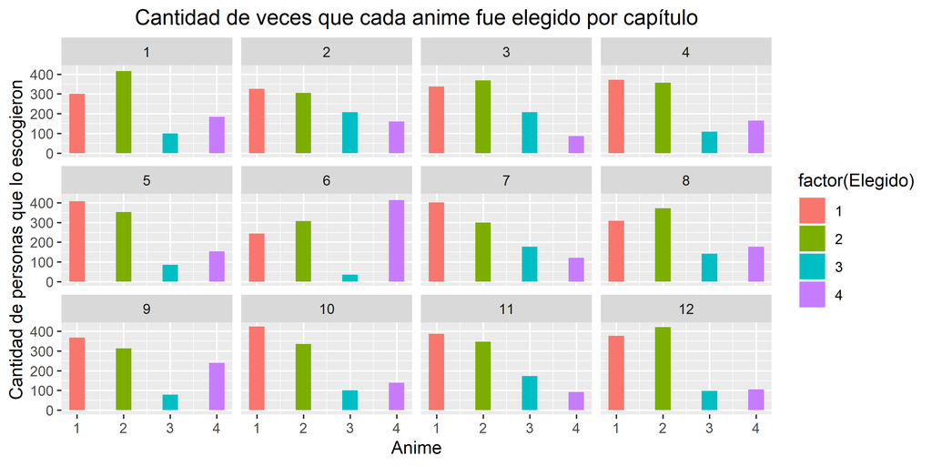

Podemos ver que los anime se diferencian bastante al verlos por capítulo, en general no se puede establecer una relación de entre mayor cantidad de capítulos aumente la calidad o el rating en la televisión.

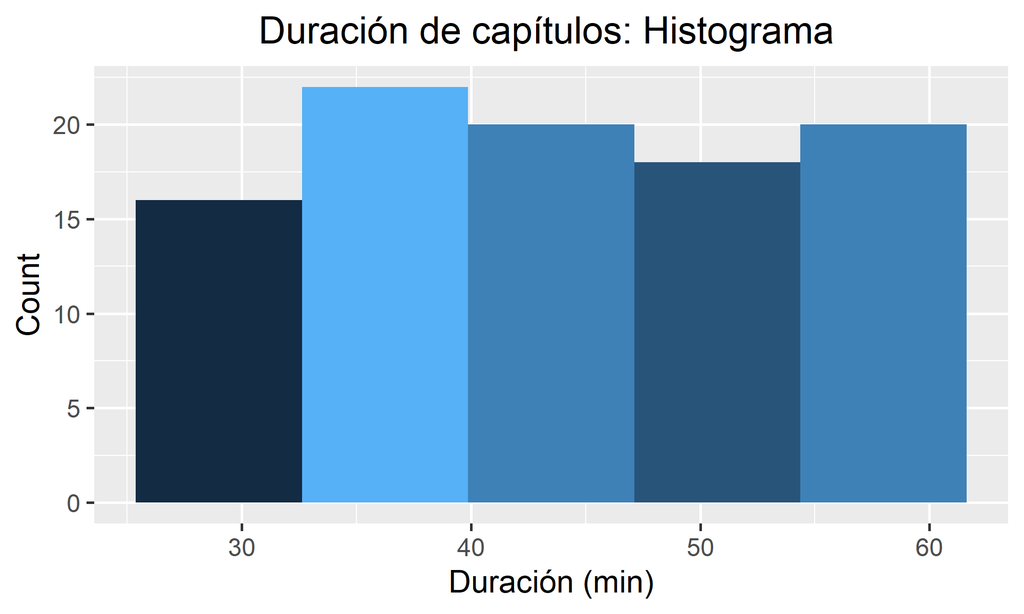

```
## [1] 96 10
```

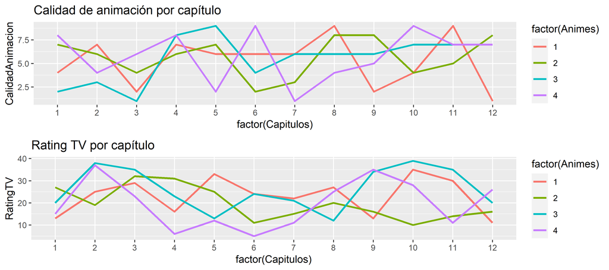

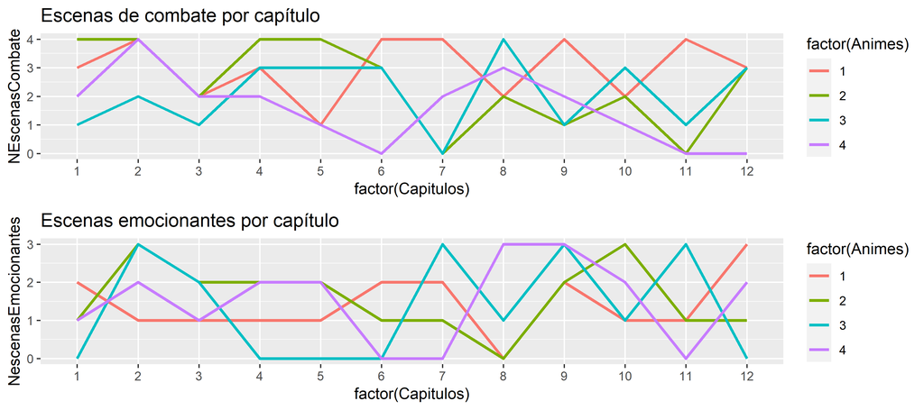

En los gráficos anteriores se puede observar que en lineas generales las escenas de combate y las emocionantes tienen correlación negativa.

Esto lo confirmamos en la siguiente matriz de correlación, donde además se puede observar que existe una correlación negativa entre el rating que tiene en televisión y la duración de los capítulos, y la calidad de la animación y el número de escenas emocionantes.

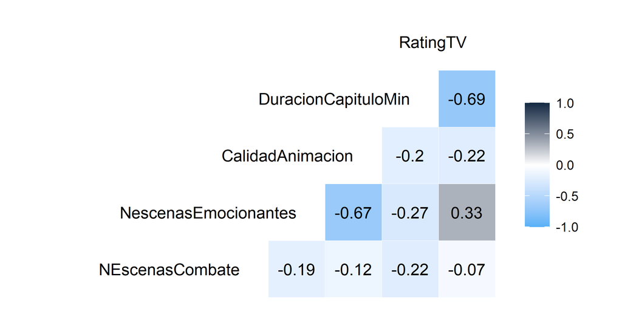

#### Pregunta 2

(2,0 puntos) Defina un modelo Logit y Mixed Logit multinomiales para estudiar las razones que llevan a un experto a elegir animes. Interprete los coeficientes y calcule la probabilidad de que una mujer de 25 años elija el anime *naruto* para el modelo logit multinomial.

```r
logit<- glm(Eleccion ~  NEscenasCombate + NescenasEmocionantes + CalidadAnimacion+ RatingTV,data=anime, family="binomial" )
summary(logit)
```

```
##
## Call:
## glm(formula = Eleccion ~ NEscenasCombate + NescenasEmocionantes +
##     CalidadAnimacion + RatingTV, family = "binomial", data = anime)
##
## Deviance Residuals:
##     Min       1Q   Median       3Q      Max
## -0.8686  -0.7894  -0.7243  -0.1258   1.7839
##
## Coefficients:
##                       Estimate Std. Error z value Pr(>|z|)
## (Intercept)          -1.341160   0.043465 -30.856  < 2e-16 ***
## NEscenasCombate       0.105600   0.008109  13.023  < 2e-16 ***
## NescenasEmocionantes  0.075201   0.011133   6.755 1.43e-11 ***
## CalidadAnimacion      0.008352   0.004649   1.797   0.0724 .
## RatingTV             -0.007223   0.001198  -6.031 1.63e-09 ***
## ---
## Signif. codes:  0 '***' 0.001 '**' 0.01 '*' 0.05 '.' 0.1 ' ' 1
##
## (Dispersion parameter for binomial family taken to be 1)
##
##     Null deviance: 53984  on 47999  degrees of freedom
## Residual deviance: 53752  on 47995  degrees of freedom
## AIC: 53762
##
## Number of Fisher Scoring iterations: 4
```

Arreglamos el data set en formato mlogit:

```
## [1] 12000    39
```

```r
#Dividimos la base en train y test
AnimeWideTrain = AnimeWide %>% group_by(Expertos) %>% sample_frac(0.7)
AnimeWideTest = anti_join(AnimeWide, AnimeWideTrain, by=c("Expertos","Capitulos"))

AnimeTrain <- subset(AnimeWideTrain, select=-c(Edad.2, Edad.3, Edad.4, Mujer.2, Mujer.3, Mujer.4))
AnimeTest <- subset(AnimeWideTest, select=-c(Edad.2, Edad.3, Edad.4, Mujer.2, Mujer.3, Mujer.4))
# Usamos mlogit.data() para formatear ambas bases
##train
myftrain <- mlogit.data(AnimeWideTrain, shape="wide", varying=3:38, sep="." ,choice="Eleccion", id = names(AnimeWide)[1:2])
## test
myftest <- mlogit.data(AnimeWideTest, shape="wide", varying=3:38, sep="." ,choice="Eleccion", id = names(AnimeWide)[1:2])
```

- Mlogit con todos

```r
modelo1<-mlogit(Eleccion ~ NEscenasCombate + NescenasEmocionantes + CalidadAnimacion+ RatingTV + DuracionCapituloMin | Edad + Mujer | 0, data = myftrain, print.level=1)
```

```
## Initial value of the function : 11090.3548889591
## iteration 1, step = 1, lnL = 10306.46709956, chi2 = 1537.06417973
## iteration 2, step = 1, lnL = 10292.3527284, chi2 = 27.69743773
## iteration 3, step = 1, lnL = 10292.32034995, chi2 = 0.0645872
## iteration 4, step = 1, lnL = 10292.32034937, chi2 = 1.15e-06
```

```r
summary(modelo1)
```

```
##
## Call:
## mlogit(formula = Eleccion ~ NEscenasCombate + NescenasEmocionantes +
##     CalidadAnimacion + RatingTV + DuracionCapituloMin | Edad +
##     Mujer | 0, data = myftrain, print.level = 1, method = "nr")
##
## Frequencies of alternatives:choice
##       1       2       3       4
## 0.35787 0.35150 0.12225 0.16837
##
## nr method
## 5 iterations, 0h:0m:2s
## g'(-H)^-1g = 1.15E-06
## successive function values within tolerance limits
##
## Coefficients :
##                         Estimate  Std. Error z-value  Pr(>|z|)
## (Intercept):2        -3.2110e-01  1.3544e-01 -2.3709  0.017747 *
## (Intercept):3        -1.4307e+00  1.8923e-01 -7.5609 3.997e-14 ***
## (Intercept):4        -8.6265e-01  1.6780e-01 -5.1409 2.735e-07 ***
## NEscenasCombate      -3.4679e-02  1.0931e-02 -3.1726  0.001511 **
## NescenasEmocionantes  5.8378e-02  1.4773e-02  3.9518 7.758e-05 ***
## CalidadAnimacion      1.0418e-02  6.0449e-03  1.7234  0.084813 .
## RatingTV              3.1701e-03  1.6181e-03  1.9591  0.050096 .
## DuracionCapituloMin   5.8932e-07  1.3658e-03  0.0004  0.999656
## Edad:2                2.4376e-03  3.5200e-03  0.6925  0.488618
## Edad:3                8.5294e-03  4.9054e-03  1.7388  0.082077 .
## Edad:4               -3.4388e-04  4.3693e-03 -0.0787  0.937268
## Mujer1:2              3.8461e-01  5.3442e-02  7.1967 6.168e-13 ***
## Mujer1:3              1.1314e-03  7.4636e-02  0.0152  0.987905
## Mujer1:4              1.5059e-01  6.6318e-02  2.2708  0.023161 *
## ---
## Signif. codes:  0 '***' 0.001 '**' 0.01 '*' 0.05 '.' 0.1 ' ' 1
##
## Log-Likelihood: -10292
## McFadden R^2:  0.004344
## Likelihood ratio test : chisq = 89.809 (p.value = 1.817e-14)
```

- Mlogit sin todos

```r
modelo_logit<-mlogit(Eleccion ~ NEscenasCombate + NescenasEmocionantes + CalidadAnimacion| Edad + Mujer | 0, data = myftrain) #La wea no cambia nada si quitar
summary(modelo_logit)
```

```
##
## Call:
## mlogit(formula = Eleccion ~ NEscenasCombate + NescenasEmocionantes +
##     CalidadAnimacion | Edad + Mujer | 0, data = myftrain, method = "nr")
##
## Frequencies of alternatives:choice
##       1       2       3       4
## 0.35787 0.35150 0.12225 0.16837
##
## nr method
## 5 iterations, 0h:0m:1s
## g'(-H)^-1g = 1E-06
## successive function values within tolerance limits
##
## Coefficients :
##                         Estimate  Std. Error z-value  Pr(>|z|)
## (Intercept):2        -0.33359784  0.13522609 -2.4670  0.013626 *
## (Intercept):3        -1.41919792  0.18902515 -7.5080 5.995e-14 ***
## (Intercept):4        -0.87248132  0.16767030 -5.2036 1.955e-07 ***
## NEscenasCombate      -0.03220384  0.01086173 -2.9649  0.003028 **
## NescenasEmocionantes  0.06153298  0.01465282  4.1994 2.676e-05 ***
## CalidadAnimacion      0.01337961  0.00581602  2.3005  0.021421 *
## Edad:2                0.00245715  0.00351998  0.6981  0.485140
## Edad:3                0.00855435  0.00490457  1.7442  0.081131 .
## Edad:4               -0.00033806  0.00436847 -0.0774  0.938315
## Mujer1:2              0.38466091  0.05344402  7.1975 6.135e-13 ***
## Mujer1:3              0.00091948  0.07461974  0.0123  0.990168
## Mujer1:4              0.15045355  0.06630670  2.2691  0.023265 *
## ---
## Signif. codes:  0 '***' 0.001 '**' 0.01 '*' 0.05 '.' 0.1 ' ' 1
##
## Log-Likelihood: -10294
## McFadden R^2:  0.0041563
## Likelihood ratio test : chisq = 85.929 (p.value = 1.0643e-14)
```

- Mixed logit *sin correlación*

```
##
## Call:
## mlogit(formula = Eleccion ~ NEscenasCombate + NescenasEmocionantes +
##     CalidadAnimacion | Edad + Mujer | 0, data = myftrain, rpar = c(`(Intercept):2` = "n",
##     `(Intercept):3` = "n", `(Intercept):4` = "n", NEscenasCombate = "n",
##     NescenasEmocionantes = "n", CalidadAnimacion = "n"), R = 100,
##     correlation = FALSE, print.level = 0)
##
## Frequencies of alternatives:choice
##       1       2       3       4
## 0.35787 0.35150 0.12225 0.16837
##
## bfgs method
## 14 iterations, 0h:1m:17s
## g'(-H)^-1g = 1.15E-07
## gradient close to zero
##
## Coefficients :
##                            Estimate  Std. Error z-value  Pr(>|z|)
## (Intercept):2           -0.33962314  0.15080032 -2.2521 0.0243135 *
## (Intercept):3           -1.52736713  0.21690875 -7.0415 1.902e-12 ***
## (Intercept):4           -1.01477419  0.19955288 -5.0852 3.672e-07 ***
## NEscenasCombate         -0.03354810  0.01362206 -2.4628 0.0137865 *
## NescenasEmocionantes     0.05656871  0.01712434  3.3034 0.0009552 ***
## CalidadAnimacion         0.00526678  0.00738811  0.7129 0.4759241
## Edad:2                   0.00308534  0.00391577  0.7879 0.4307399
## Edad:3                   0.00963839  0.00558803  1.7248 0.0845582 .
## Edad:4                   0.00031801  0.00505734  0.0629 0.9498620
## Mujer1:2                 0.43977837  0.06107232  7.2009 5.980e-13 ***
## Mujer1:3                 0.03205843  0.08162188  0.3928 0.6944911
## Mujer1:4                 0.17719733  0.07508882  2.3598 0.0182830 *
## sd.(Intercept):2         0.02769384  0.24503089  0.1130 0.9100133
## sd.(Intercept):3         0.03261740  0.33074159  0.0986 0.9214408
## sd.(Intercept):4         0.25464333  0.29900243  0.8516 0.3944123
## sd.NEscenasCombate       0.42667649  0.04256417 10.0243 < 2.2e-16 ***
## sd.NescenasEmocionantes -0.26223759  0.07610661 -3.4457 0.0005697 ***
## sd.CalidadAnimacion      0.14022792  0.03249002  4.3160 1.589e-05 ***
## ---
## Signif. codes:  0 '***' 0.001 '**' 0.01 '*' 0.05 '.' 0.1 ' ' 1
##
## Log-Likelihood: -10255
## McFadden R^2:  0.0079169
## Likelihood ratio test : chisq = 163.68 (p.value = < 2.22e-16)
##
## random coefficients
##                      Min.     1st Qu.       Median         Mean     3rd Qu.
## (Intercept):2        -Inf -0.35830235 -0.339623144 -0.339623144 -0.32094393
## (Intercept):3        -Inf -1.54936723 -1.527367125 -1.527367125 -1.50536702
## (Intercept):4        -Inf -1.18652851 -1.014774194 -1.014774194 -0.84301988
## NEscenasCombate      -Inf -0.32133702 -0.033548099 -0.033548099  0.25424082
## NescenasEmocionantes -Inf -0.12030786  0.056568709  0.056568709  0.23344527
## CalidadAnimacion     -Inf -0.08931551  0.005266784  0.005266784  0.09984908
##                      Max.
## (Intercept):2         Inf
## (Intercept):3         Inf
## (Intercept):4         Inf
## NEscenasCombate       Inf
## NescenasEmocionantes  Inf
## CalidadAnimacion      Inf
```

```
## $`(Intercept):2`
## normal distribution with parameters -0.34 (mean) and 0.028 (sd)
##
## $`(Intercept):3`
## normal distribution with parameters -1.527 (mean) and 0.033 (sd)
##
## $`(Intercept):4`
## normal distribution with parameters -1.015 (mean) and 0.255 (sd)
##
## $NEscenasCombate
## normal distribution with parameters -0.034 (mean) and 0.427 (sd)
##
## $NescenasEmocionantes
## normal distribution with parameters 0.057 (mean) and -0.262 (sd)
##
## $CalidadAnimacion
## normal distribution with parameters 0.005 (mean) and 0.14 (sd)
```

- Mixed logit *con correlación*

```
##
## Call:
## mlogit(formula = Eleccion ~ NEscenasCombate + NescenasEmocionantes +
##     CalidadAnimacion | Edad + Mujer | 0, data = myftrain, rpar = c(`(Intercept):2` = "n",
##     `(Intercept):3` = "n", `(Intercept):4` = "n", NEscenasCombate = "n",
##     NescenasEmocionantes = "n", CalidadAnimacion = "n"), R = 100,
##     correlation = TRUE, print.level = 0)
##
## Frequencies of alternatives:choice
##       1       2       3       4
## 0.35787 0.35150 0.12225 0.16837
##
## bfgs method
## 80 iterations, 0h:6m:59s
## g'(-H)^-1g = 5.21E-07
## gradient close to zero
##
## Coefficients :
##                                                  Estimate Std. Error z-value
## (Intercept):2                                  -0.1609357  0.3729889 -0.4315
## (Intercept):3                                  -1.4486671  0.3765777 -3.8469
## (Intercept):4                                  -1.8470981  0.5434734 -3.3987
## NEscenasCombate                                 0.0916663  0.0402814  2.2756
## NescenasEmocionantes                           -0.1439144  0.0582184 -2.4720
## CalidadAnimacion                                0.0143701  0.0200820  0.7156
## Edad:2                                          0.0072562  0.0094879  0.7648
## Edad:3                                          0.0168039  0.0092337  1.8198
## Edad:4                                          0.0057142  0.0115978  0.4927
## Mujer1:2                                        1.0301619  0.1984413  5.1913
## Mujer1:3                                        0.2297288  0.1479098  1.5532
## Mujer1:4                                        0.7048832  0.2062327  3.4179
## chol.(Intercept):2:(Intercept):2                3.9918062  0.7336335  5.4411
## chol.(Intercept):2:(Intercept):3                1.8372701  0.5264982  3.4896
## chol.(Intercept):3:(Intercept):3                1.8002795  0.2997243  6.0065
## chol.(Intercept):2:(Intercept):4                4.2179602  0.7799934  5.4077
## chol.(Intercept):3:(Intercept):4                2.5654553  0.4394447  5.8379
## chol.(Intercept):4:(Intercept):4                0.2157465  0.3489201  0.6183
## chol.(Intercept):2:NEscenasCombate              0.1074998  0.0793898  1.3541
## chol.(Intercept):3:NEscenasCombate              0.3704266  0.0993212  3.7296
## chol.(Intercept):4:NEscenasCombate              0.0058743  0.1410384  0.0417
```

[output cut: 46 more lines]

```
## ---
## Signif. codes:  0 '***' 0.001 '**' 0.01 '*' 0.05 '.' 0.1 ' ' 1
##
## Log-Likelihood: -10182
## McFadden R^2:  0.015006
## Likelihood ratio test : chisq = 310.23 (p.value = < 2.22e-16)
##
## random coefficients
##                      Min.    1st Qu.      Median        Mean   3rd Qu. Max.
## (Intercept):2        -Inf -2.8533681 -0.16093574 -0.16093574 2.5314966  Inf
## (Intercept):3        -Inf -3.1836361 -1.44866707 -1.44866707 0.2863020  Inf
## (Intercept):4        -Inf -5.1801488 -1.84709810 -1.84709810 1.4859526  Inf
## NEscenasCombate      -Inf -0.7033812  0.09166627  0.09166627 0.8867137  Inf
## NescenasEmocionantes -Inf -0.8637278 -0.14391441 -0.14391441 0.5758990  Inf
## CalidadAnimacion     -Inf -0.2732111  0.01437006  0.01437006 0.3019512  Inf
```

```
## $`(Intercept):2`
## normal distribution with parameters -0.161 (mean) and 3.992 (sd)
##
## $`(Intercept):3`
## normal distribution with parameters -1.449 (mean) and 2.572 (sd)
##
## $`(Intercept):4`
## normal distribution with parameters -1.847 (mean) and 4.942 (sd)
##
## $NEscenasCombate
## normal distribution with parameters 0.092 (mean) and 1.179 (sd)
##
## $NescenasEmocionantes
## normal distribution with parameters -0.144 (mean) and 1.067 (sd)
##
## $CalidadAnimacion
## normal distribution with parameters 0.014 (mean) and 0.426 (sd)
```

#### Pregunta 3

(1,0 puntos) Construya un modelo Probit que capture los elementos de elección principales y comente sobre cómo se interpretan sus coeficientes.

```r
modelo_probit1<-mlogit(Eleccion ~  NEscenasCombate + NescenasEmocionantes + CalidadAnimacion | 1 | 0, data = myftrain, probit = TRUE, print.level=1)
```

```
## Initial value of the function : 10330.1558914514
## iteration 1, step = 0.25, lnL = 10322.93550506, chi2 = 72.69622353
## iteration 2, step = 0.015625, lnL = 10322.71671992, chi2 = 162.33535656
## iteration 3, step = 0.0078125, lnL = 10315.57629851, chi2 = 2115.41732957
## iteration 4, step = 0.03125, lnL = 10312.7393996, chi2 = 753.38700074
## iteration 5, step = 0.0625, lnL = 10312.48298242, chi2 = 211.60243541
## iteration 6, step = 0.25, lnL = 10310.26179861, chi2 = 21.76074471
## iteration 7, step = 0.25, lnL = 10309.30950243, chi2 = 37.68385172
## iteration 8, step = 1, lnL = 10303.01673304, chi2 = 17.16467768
## iteration 9, step = 0.125, lnL = 10301.66887772, chi2 = 36.10990332
## iteration 10, step = 0.5, lnL = 10300.10788057, chi2 = 9.52234706
## iteration 11, step = 1, lnL = 10299.86857825, chi2 = 5.81636876
## iteration 12, step = 1, lnL = 10297.03802227, chi2 = 5.62473363
## iteration 13, step = 0.25, lnL = 10296.31427118, chi2 = 7.88999945
## iteration 14, step = 0.5, lnL = 10295.67000876, chi2 = 2.90712962
## iteration 15, step = 1, lnL = 10294.63568674, chi2 = 3.69846883
## iteration 16, step = 1, lnL = 10292.98259931, chi2 = 5.03261722
## iteration 17, step = 0.5, lnL = 10291.79704198, chi2 = 6.63530713
## iteration 18, step = 0.5, lnL = 10291.76808009, chi2 = 5.36823022
## iteration 19, step = 0.5, lnL = 10290.88627298, chi2 = 8.88633928
## iteration 20, step = 0.5, lnL = 10289.13850279, chi2 = 7.62843876
## iteration 21, step = 0.5, lnL = 10288.23717992, chi2 = 2.76316978
## iteration 22, step = 0.25, lnL = 10287.6235507, chi2 = 3.63312911
## iteration 23, step = 0.5, lnL = 10287.52678504, chi2 = 2.25902257
## iteration 24, step = 0.5, lnL = 10286.98154545, chi2 = 2.65382541
## iteration 25, step = 0.5, lnL = 10286.33219361, chi2 = 2.56872224
## iteration 26, step = 0.25, lnL = 10286.21709708, chi2 = 1.26790371
## iteration 27, step = 0.5, lnL = 10285.9047606, chi2 = 1.66741615
## iteration 28, step = 0.125, lnL = 10285.70258452, chi2 = 2.56762576
## iteration 29, step = 0.25, lnL = 10285.46305118, chi2 = 2.84948876
## iteration 30, step = 0.25, lnL = 10285.24183513, chi2 = 2.19680397
## iteration 31, step = 0.25, lnL = 10285.20971867, chi2 = 0.97609592
## iteration 32, step = 0.5, lnL = 10284.95895908, chi2 = 0.63581648
## iteration 33, step = 0.0625, lnL = 10284.87113713, chi2 = 2.09997819
## iteration 34, step = 0.125, lnL = 10284.82908664, chi2 = 0.77109239
## iteration 35, step = 0.5, lnL = 10284.73551582, chi2 = 0.28722236
## iteration 36, step = 0.125, lnL = 10284.69354829, chi2 = 1.19959508
## iteration 37, step = 0.25, lnL = 10284.64769224, chi2 = 0.71635176
## iteration 38, step = 0.25, lnL = 10284.58773228, chi2 = 1.00040836
## iteration 39, step = 0.5, lnL = 10284.5844535, chi2 = 0.39989436
```

[output cut: 30 more lines]

```
## iteration 70, step = 1, lnL = 10281.62029191, chi2 = 0.00437071
## iteration 71, step = 1, lnL = 10281.61948392, chi2 = 0.00173425
## iteration 72, step = 1, lnL = 10281.61926146, chi2 = 0.00036693
## iteration 73, step = 1, lnL = 10281.61857234, chi2 = 0.00070153
## iteration 74, step = 0.0625, lnL = 10281.61667113, chi2 = 0.05937733
## iteration 75, step = 1, lnL = 10281.61543016, chi2 = 0.00159343
## iteration 76, step = 1, lnL = 10281.61454486, chi2 = 0.00515979
## iteration 77, step = 1, lnL = 10281.61360725, chi2 = 0.00462942
## iteration 78, step = 1, lnL = 10281.61255254, chi2 = 0.00211014
## iteration 79, step = 1, lnL = 10281.61250836, chi2 = 0.00011019
## iteration 80, step = 1, lnL = 10281.61249681, chi2 = 2.719e-05
## iteration 81, step = 1, lnL = 10281.61249035, chi2 = 1.468e-05
## iteration 82, step = 1, lnL = 10281.61248769, chi2 = 5.49e-06
## iteration 83, step = 1, lnL = 10281.61248683, chi2 = 1.33e-06
## iteration 84, step = 1, lnL = 10281.61248651, chi2 = 5.2e-07
```

```r
summary(modelo_probit1)
```

```
##
## Call:
## mlogit(formula = Eleccion ~ NEscenasCombate + NescenasEmocionantes +
##     CalidadAnimacion | 1 | 0, data = myftrain, probit = TRUE,
##     print.level = 1)
##
## Frequencies of alternatives:choice
##       1       2       3       4
## 0.35787 0.35150 0.12225 0.16837
##
## bfgs method
## 84 iterations, 1h:18m:25s
## g'(-H)^-1g = 5.18E-07
## gradient close to zero
##
## Coefficients :
##                         Estimate  Std. Error z-value  Pr(>|z|)
## (Intercept):2         3.2792e-01  5.1993e-02  6.3069 2.847e-10 ***
## (Intercept):3         3.2717e-01  5.2672e-02  6.2116 5.245e-10 ***
## (Intercept):4         3.2778e-01  5.1845e-02  6.3222 2.578e-10 ***
## NEscenasCombate      -2.1961e-04  5.6864e-04 -0.3862    0.6994
## NescenasEmocionantes  1.5321e-04  4.0061e-04  0.3824    0.7021
## CalidadAnimacion      4.7452e-05  1.2320e-04  0.3852    0.7001
## 2.3                   9.7903e-01  3.5716e-02 27.4119 < 2.2e-16 ***
## 2.4                   9.7863e-01  3.6178e-02 27.0507 < 2.2e-16 ***
## 3.3                   7.9890e-02  1.0752e-01  0.7430    0.4575
## 3.4                   7.9762e-02  1.0731e-01  0.7433    0.4573
## 4.4                   2.2228e-03  5.7843e-03  0.3843    0.7008
## ---
## Signif. codes:  0 '***' 0.001 '**' 0.01 '*' 0.05 '.' 0.1 ' ' 1
##
## Log-Likelihood: -10282
## McFadden R^2:  0.0053798
## Likelihood ratio test : chisq = 111.22 (p.value = < 2.22e-16)
```

```r
modelo_probit<-mlogit(Eleccion ~  NEscenasCombate + NescenasEmocionantes + CalidadAnimacion | Mujer | 0, data = myftrain, probit = TRUE, print.level=1)
```

```
## Initial value of the function : 10300.1521768279
## iteration 1, step = 0.25, lnL = 10291.43982069, chi2 = 71.872402
## iteration 2, step = 0.125, lnL = 10284.49770581, chi2 = 144.79368359
## iteration 3, step = 0.00390625, lnL = 10282.93716978, chi2 = 1017.21994006
## iteration 4, step = 0.03125, lnL = 10282.53460137, chi2 = 1025.55099119
## iteration 5, step = 0.0625, lnL = 10282.12852767, chi2 = 54.86229703
## iteration 6, step = 0.0625, lnL = 10281.53437703, chi2 = 30.32365858
## iteration 7, step = 0.25, lnL = 10276.33555399, chi2 = 33.73813946
## iteration 8, step = 0.25, lnL = 10273.87296749, chi2 = 12.81340599
## iteration 9, step = 0.5, lnL = 10273.55970665, chi2 = 16.00842162
## iteration 10, step = 0.5, lnL = 10270.51314079, chi2 = 24.23188525
## iteration 11, step = 0.25, lnL = 10268.73831795, chi2 = 28.9562464
## iteration 12, step = 0.25, lnL = 10268.54003051, chi2 = 26.54478041
## iteration 13, step = 0.5, lnL = 10267.63606844, chi2 = 10.76134171
## iteration 14, step = 0.25, lnL = 10267.30732368, chi2 = 15.7015763
## iteration 15, step = 0.5, lnL = 10266.68906916, chi2 = 10.98289363
## iteration 16, step = 1, lnL = 10265.81317905, chi2 = 5.23640446
## iteration 17, step = 1, lnL = 10265.17324957, chi2 = 7.59815502
## iteration 18, step = 1, lnL = 10264.1987785, chi2 = 6.61859115
## iteration 19, step = 0.5, lnL = 10263.25727852, chi2 = 4.32752332
## iteration 20, step = 0.5, lnL = 10262.25444076, chi2 = 4.93726288
## iteration 21, step = 0.5, lnL = 10261.53214749, chi2 = 4.04364423
## iteration 22, step = 1, lnL = 10260.80034705, chi2 = 2.98472423
## iteration 23, step = 0.25, lnL = 10259.95018315, chi2 = 6.98633016
## iteration 24, step = 0.5, lnL = 10258.59300409, chi2 = 5.39623984
## iteration 25, step = 0.25, lnL = 10258.14255032, chi2 = 3.70371833
## iteration 26, step = 0.125, lnL = 10257.71624237, chi2 = 6.32901967
## iteration 27, step = 0.5, lnL = 10257.28854693, chi2 = 3.70119395
## iteration 28, step = 0.5, lnL = 10256.64333992, chi2 = 2.90479991
## iteration 29, step = 0.25, lnL = 10256.0525291, chi2 = 5.2534316
## iteration 30, step = 0.25, lnL = 10255.78666192, chi2 = 2.62216182
## iteration 31, step = 0.5, lnL = 10255.61254911, chi2 = 2.20203349
## iteration 32, step = 0.25, lnL = 10255.32434384, chi2 = 3.35255693
## iteration 33, step = 0.125, lnL = 10255.09428619, chi2 = 4.92474912
## iteration 34, step = 0.125, lnL = 10254.87328972, chi2 = 8.19279617
## iteration 35, step = 0.125, lnL = 10254.66595378, chi2 = 3.07462135
## iteration 36, step = 0.25, lnL = 10254.36593869, chi2 = 2.90342984
## iteration 37, step = 0.0625, lnL = 10254.24949639, chi2 = 2.97352766
## iteration 38, step = 0.25, lnL = 10254.24400801, chi2 = 2.48050655
## iteration 39, step = 0.03125, lnL = 10254.19372985, chi2 = 3.61210568
```

[output cut: 16 more lines]

```
## iteration 56, step = 0.0625, lnL = 10251.97702794, chi2 = 0.2771443
## iteration 57, step = 0.5, lnL = 10251.96519473, chi2 = 0.06978115
## iteration 58, step = 1, lnL = 10251.96194882, chi2 = 0.01184272
## iteration 59, step = 0.5, lnL = 10251.96023939, chi2 = 0.00680504
## iteration 60, step = 1, lnL = 10251.95969802, chi2 = 0.00294691
## iteration 61, step = 1, lnL = 10251.95888115, chi2 = 0.0014949
## iteration 62, step = 1, lnL = 10251.95864232, chi2 = 0.00036921
## iteration 63, step = 1, lnL = 10251.95839125, chi2 = 0.00034553
## iteration 64, step = 1, lnL = 10251.95810279, chi2 = 0.00040307
## iteration 65, step = 1, lnL = 10251.95779722, chi2 = 0.00043643
## iteration 66, step = 1, lnL = 10251.95753924, chi2 = 0.00038454
## iteration 67, step = 1, lnL = 10251.95738889, chi2 = 0.00024352
## iteration 68, step = 1, lnL = 10251.95737099, chi2 = 3.413e-05
## iteration 69, step = 1, lnL = 10251.95737042, chi2 = 1.26e-06
## iteration 70, step = 1, lnL = 10251.95737035, chi2 = 1.4e-07
```

```r
summary(modelo_probit)
```

```
##
## Call:
## mlogit(formula = Eleccion ~ NEscenasCombate + NescenasEmocionantes +
##     CalidadAnimacion | Mujer | 0, data = myftrain, probit = TRUE,
##     print.level = 1)
##
## Frequencies of alternatives:choice
##       1       2       3       4
## 0.35787 0.35150 0.12225 0.16837
##
## bfgs method
## 70 iterations, 1h:19m:30s
## g'(-H)^-1g = 1.43E-07
## gradient close to zero
##
## Coefficients :
##                         Estimate  Std. Error z-value  Pr(>|z|)
## (Intercept):2         0.24984391  0.05848245  4.2721 1.936e-05 ***
## (Intercept):3         0.25767996  0.04865472  5.2961 1.183e-07 ***
## (Intercept):4         0.25819199  0.04799426  5.3796 7.463e-08 ***
## NEscenasCombate      -0.00021515  0.00056283 -0.3823    0.7023
## NescenasEmocionantes  0.00015225  0.00040195  0.3788    0.7049
## CalidadAnimacion      0.00004617  0.00012111  0.3812    0.7030
## Mujer1:2              0.15887928  0.03012975  5.2732 1.341e-07 ***
## Mujer1:3              0.14177290  0.03129135  4.5307 5.878e-06 ***
## Mujer1:4              0.14195545  0.03119365  4.5508 5.345e-06 ***
## 2.3                   0.97853308  0.03597637 27.1993 < 2.2e-16 ***
## 2.4                   0.97811612  0.03643696 26.8441 < 2.2e-16 ***
## 3.3                   0.08229550  0.10796690  0.7622    0.4459
## 3.4                   0.08217936  0.10777253  0.7625    0.4457
## 4.4                   0.00218318  0.00573831  0.3805    0.7036
## ---
## Signif. codes:  0 '***' 0.001 '**' 0.01 '*' 0.05 '.' 0.1 ' ' 1
##
## Log-Likelihood: -10252
## McFadden R^2:  0.0082486
## Likelihood ratio test : chisq = 170.54 (p.value = < 2.22e-16)
```

#### Pregunta 4

(2,0 puntos) Utilizando lo aprendido de los modelos anteriores, construya dos modelos de *machine learning* diferentes y compárelos con los modelos logits y probits estimados anteriormente, para ello calcule la matriz de confusión de cada modelo respecto a su predicción y utilice métricas derivadas a partir de esta para la comparación de los modelos.

Primero obtendremos las métricas para los modelos logit y probit

Obtenemos matriz de confusión de modelo logit

```r
predictLogit <- predict(modelo_logit, newdata = myftest) #proporciona una matriz de probabilidades de elección de cada alternativa (4 columnas)
predictLogit = as.matrix(max.col(predictLogit))  #vector que contiene la alternativa con mayor probabilidad (la más probable a escoger) para cada experto en cada instancia capitulo

table(predictLogit)
```

```
## predictLogit
##    1    2
## 2040 1960
```

```r
predictLogit[predictLogit==1]="HxH"
predictLogit[predictLogit==2]="DB"
predictLogit[predictLogit==3]="N"
predictLogit[predictLogit==4]="BNHA"

# Para comparar la predicción vs lo real, necesitamos lo que realmente escogieron en cada instancia de capitulo los expertos en la base test

#Ejemplo cálculo del hit rate
r<-ifelse(test1==predictLogit,1,0) #un indicador binario: 1 si el modelo le achuntó, 0 en caso contrario
hitrate <-sum(r)/4000 # cantidad de veces que se achuntó dividido por el total de filas base test (30%*48000 del total de la base)
hitrate
```

```
## [1] 0.3845
```

```r
#Calculo manual de la Matriz de Confusión
true_choice = as.factor(test1) #verdadera elección como factor
predictLogit =as.factor(predictLogit) #predicciones como factor
predictLogit <- factor(predictLogit , levels = c("HxH","DB","N","BNHA"))
MatrizConf=table(true_choice , predictLogit )
MatrizConf
```

```
##            predictLogit
## true_choice HxH  DB   N BNHA
##        BNHA 352 338   0    0
##        DB   619 765   0    0
##        HxH  773 620   0    0
##        N    296 237   0    0
```

Obtenemos matriz de confusión de modelo probit

```r
predictProbit <- predict(modelo_probit, newdata = myftest)
predictProbit = as.matrix(max.col(predictProbit))

predictProbit[predictProbit==1]="HxH"
predictProbit[predictProbit==2]="DB"
predictProbit[predictLogit==3]="N"
predictProbit[predictProbit==4]="BNHA"

r<-ifelse(test1==predictProbit,1,0)
hitrate <-sum(r)/4000
hitrate
```

```
## [1] 0.3845
```

```r
#Calculo manual de la Matriz de Confusión
true_choice = as.factor(test1) #verdadera elección como factor
predictProbit =as.factor(predictProbit) #predicciones como factor
predictProbit <- factor(predictProbit , levels = c("HxH","DB","N","BNHA"))
MatrizConf=table(true_choice , predictProbit )
MatrizConf
```

```
##            predictProbit
## true_choice HxH  DB   N BNHA
##        BNHA 352 338   0    0
##        DB   619 765   0    0
##        HxH  773 620   0    0
##        N    296 237   0    0
```

```r
#ML 1: SVM
train.svm <- train(Eleccion ~ NEscenasCombate.1 + NEscenasCombate.2 + NEscenasCombate.3 + NEscenasCombate.4 + NescenasEmocionantes.1 + NescenasEmocionantes.2 + NescenasEmocionantes.3 + NescenasEmocionantes.4 + CalidadAnimacion.1 + CalidadAnimacion.2 + CalidadAnimacion.3 + CalidadAnimacion.4 + Mujer.1, data = AnimeTrain, method = "svmLinear2",
                   trControl  = trainControl("cv", number=5, verbose=TRUE, classProbs=TRUE,
                                             summaryFunction=multiClassSummary),
                   preProcess = c("center","scale"),
                   tuneLength = 3,
                   metric = "ROC")
```

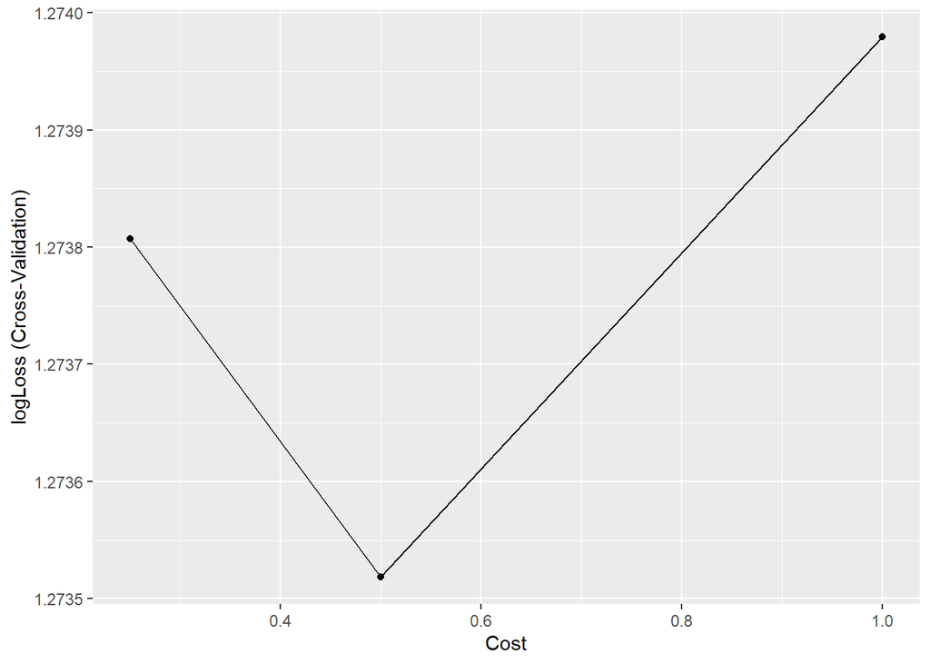

```r
ggplot(train.svm)
```

```r
train.svm$results
```

```
##   cost  logLoss       AUC     prAUC  Accuracy      Kappa Mean_F1
## 1 0.25 1.273807 0.5663348 0.2720843 0.3938775 0.08192455     NaN
## 2 0.50 1.273518 0.5721845 0.2759118 0.3938775 0.08192455     NaN
## 3 1.00 1.273979 0.5695897 0.2752001 0.3938775 0.08192455     NaN
##   Mean_Sensitivity Mean_Specificity Mean_Pos_Pred_Value Mean_Neg_Pred_Value
## 1        0.3022556        0.7693795                 NaN           0.7715275
## 2        0.3022556        0.7693795                 NaN           0.7715275
## 3        0.3022556        0.7693795                 NaN           0.7715275
##   Mean_Precision Mean_Recall Mean_Detection_Rate Mean_Balanced_Accuracy
## 1            NaN   0.3022556          0.09846939              0.5358176
## 2            NaN   0.3022556          0.09846939              0.5358176
## 3            NaN   0.3022556          0.09846939              0.5358176
##     logLossSD       AUCSD     prAUCSD  AccuracySD    KappaSD Mean_F1SD
## 1 0.002314054 0.008684155 0.003364851 0.008790093 0.01278005        NA
## 2 0.004388663 0.012478891 0.004645101 0.008790093 0.01278005        NA
## 3 0.003798134 0.009980138 0.003879317 0.008790093 0.01278005        NA
##   Mean_SensitivitySD Mean_SpecificitySD Mean_Pos_Pred_ValueSD
## 1        0.005418603        0.003382764                    NA
## 2        0.005418603        0.003382764                    NA
## 3        0.005418603        0.003382764                    NA
##   Mean_Neg_Pred_ValueSD Mean_PrecisionSD Mean_RecallSD Mean_Detection_RateSD
## 1           0.004224038               NA   0.005418603           0.002197523
## 2           0.004224038               NA   0.005418603           0.002197523
## 3           0.004224038               NA   0.005418603           0.002197523
##   Mean_Balanced_AccuracySD
## 1              0.004259805
## 2              0.004259805
## 3              0.004259805
```

```r
test.svm <- predict(train.svm, newdata=AnimeTest)
test.svm1 <- as.factor(test.svm)
CM.svm   <- confusionMatrix(test.svm1, test1)

CM.svm
```

```
## Confusion Matrix and Statistics
##
##           Reference
## Prediction BNHA  DB HxH   N
##       BNHA  161  95  86  16
##       DB    263 711 585 229
##       HxH   266 578 722 288
##       N       0   0   0   0
##
## Overall Statistics
##
##                Accuracy : 0.3985
##                  95% CI : (0.3833, 0.4139)
##     No Information Rate : 0.3482
##     P-Value [Acc > NIR] : 2.211e-11
##
##                   Kappa : 0.1002
##
##  Mcnemar's Test P-Value : < 2.2e-16
##
## Statistics by Class:
##
##                      Class: BNHA Class: DB Class: HxH Class: N
## Sensitivity              0.23333    0.5137     0.5183   0.0000
## Specificity              0.94048    0.5883     0.5658   1.0000
## Pos Pred Value           0.44972    0.3977     0.3894      NaN
## Neg Pred Value           0.85475    0.6958     0.6873   0.8668
## Prevalence               0.17250    0.3460     0.3483   0.1333
## Detection Rate           0.04025    0.1777     0.1805   0.0000
## Detection Prevalence     0.08950    0.4470     0.4635   0.0000
## Balanced Accuracy        0.58691    0.5510     0.5420   0.5000
```

```r
#ML2: Random Forest
train.randomf <- train(Eleccion ~ NEscenasCombate.1 + NEscenasCombate.2 + NEscenasCombate.3 + NEscenasCombate.4 + NescenasEmocionantes.1 + NescenasEmocionantes.2 + NescenasEmocionantes.3 + NescenasEmocionantes.4 + CalidadAnimacion.1 + CalidadAnimacion.2 + CalidadAnimacion.3 + CalidadAnimacion.4 + Mujer.1,
                       data=AnimeTrain, method="parRF",
                       trControl  = trainControl("cv", number=5, allowParallel=TRUE, verbose=TRUE,
                                                 classProbs=TRUE, summaryFunction=multiClassSummary),
                       preProcess = c("center","scale"),
                       tuneLength = 3,
                       metric = "ROC")
```

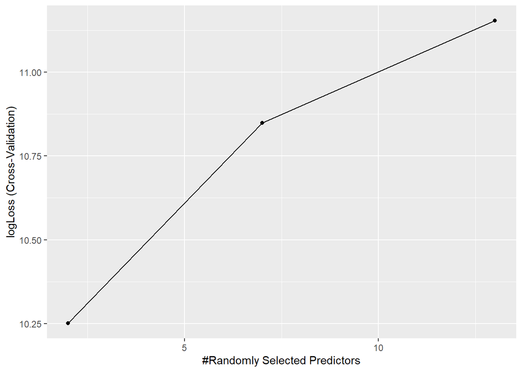

```r
ggplot(train.randomf)
```

```r
train.randomf$results
```

```
##   mtry  logLoss       AUC     prAUC  Accuracy      Kappa Mean_F1
## 1    2 10.25068 0.5485839 0.2809903 0.3940006 0.08157051     NaN
## 2    7 10.84817 0.5480836 0.2615642 0.3988802 0.08877143     NaN
## 3   13 11.15316 0.5507512 0.2757181 0.3960044 0.08034769     NaN
##   Mean_Sensitivity Mean_Specificity Mean_Pos_Pred_Value Mean_Neg_Pred_Value
## 1        0.3020330        0.7692853                 NaN           0.7720226
## 2        0.3053805        0.7711264                 NaN           0.7745349
## 3        0.2975874        0.7693055                 NaN           0.7727435
##   Mean_Precision Mean_Recall Mean_Detection_Rate Mean_Balanced_Accuracy
## 1            NaN   0.3020330          0.09850015              0.5356592
## 2            NaN   0.3053805          0.09972005              0.5382535
## 3            NaN   0.2975874          0.09900109              0.5334465
##   logLossSD       AUCSD    prAUCSD  AccuracySD     KappaSD Mean_F1SD
## 1 0.1978262 0.007516434 0.02304715 0.007009929 0.009625769        NA
## 2 0.5163873 0.005233123 0.01505691 0.016252225 0.025016381        NA
## 3 0.5443885 0.009527313 0.01636791 0.015505035 0.024882357        NA
##   Mean_SensitivitySD Mean_SpecificitySD Mean_Pos_Pred_ValueSD
## 1        0.006286774        0.002341089                    NA
## 2        0.014420411        0.006103169                    NA
## 3        0.014994000        0.005992605                    NA
##   Mean_Neg_Pred_ValueSD Mean_PrecisionSD Mean_RecallSD Mean_Detection_RateSD
## 1           0.002612483               NA   0.006286774           0.001752482
## 2           0.007381284               NA   0.014420411           0.004063056
## 3           0.006965522               NA   0.014994000           0.003876259
##   Mean_Balanced_AccuracySD
## 1              0.004145032
## 2              0.010238128
## 3              0.010450754
```

```r
test.randomf <- predict(train.randomf, newdata=AnimeTest)
test.randomf1 <- as.factor(test.randomf)
CM.randomf   <-confusionMatrix(test.randomf1, test1)
CM.randomf
```

```
## Confusion Matrix and Statistics
##
##           Reference
## Prediction BNHA  DB HxH   N
##       BNHA  161  95  86  16
##       DB    235 628 553 252
##       HxH   294 661 754 265
##       N       0   0   0   0
##
## Overall Statistics
##
##                Accuracy : 0.3858
##                  95% CI : (0.3706, 0.401)
##     No Information Rate : 0.3482
##     P-Value [Acc > NIR] : 4.215e-07
##
##                   Kappa : 0.081
##
##  Mcnemar's Test P-Value : < 2.2e-16
##
## Statistics by Class:
##
##                      Class: BNHA Class: DB Class: HxH Class: N
## Sensitivity              0.23333    0.4538     0.5413   0.0000
## Specificity              0.94048    0.6024     0.5320   1.0000
## Pos Pred Value           0.44972    0.3765     0.3820      NaN
## Neg Pred Value           0.85475    0.6758     0.6846   0.8668
## Prevalence               0.17250    0.3460     0.3483   0.1333
## Detection Rate           0.04025    0.1570     0.1885   0.0000
## Detection Prevalence     0.08950    0.4170     0.4935   0.0000
## Balanced Accuracy        0.58691    0.5281     0.5367   0.5000
```

#### Pregunta 5

(1,0 puntos) Resuma sus aprendizajes principales en un máximo de 4 tablas o figuras. Redacte de manera concisa sus resultados tal como los reportaría al departamento comercial interesado en informarse de la preferencia de los expertos. Agregue cualquier conclusión o idea que le parezca relevante de comunicar para que los representantes del canal de televisión tomen la mejor estrategia de programación televisiva.

```r
#Resuma
```

[output not shown]

## Anexos

Documenta acá cualquier otro adicional que consideres útil tener de referencia.